# Correlation Analysis

Load the data

```r
data <- read.csv("data/train_raw.csv", header = TRUE)
```

Correlation plot

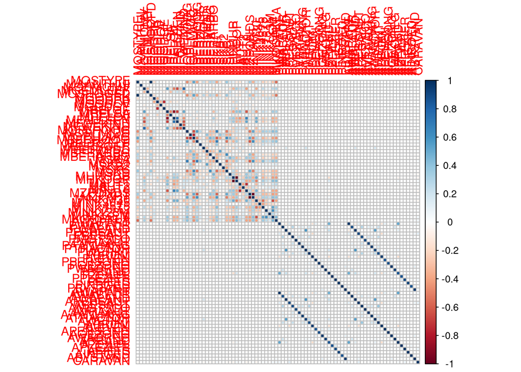

```r
library(corrplot)
cor_matrix <- cor(data)
corrplot(cor_matrix, method = "circle")
```

Let’s find the most correlated explanatory variables, which could cause multicollinearity. We do not take in consideration the target variable, which is the last one.

```r
multicorr_columns <- c()
n_col <- ncol(cor_matrix) - 1 #exclude the target variable
corr_threshold <- 0.7

for (i in seq_len(n_col - 1)) {
  for (j in seq(i + 1, n_col)) {
    if (abs(cor_matrix[i, j]) > corr_threshold) {
      print(paste(colnames(cor_matrix)[i], colnames(cor_matrix)[j],
                  cor_matrix[i, j]))
      multicorr_columns <- c(multicorr_columns, colnames(cor_matrix)[j])
    }
  }
}
```

```
## [1] "MOSTYPE MOSHOOFD 0.992671873587132"
## [1] "MGEMOMV MFWEKIND 0.79401424585324"
## [1] "MGODPR MGODGE -0.741894510538976"
## [1] "MRELGE MRELOV -0.884361887633466"
## [1] "MRELOV MFALLEEN 0.745642268891389"
## [1] "MOPLMIDD MOPLLAAG -0.747581567682011"
## [1] "MHHUUR MHKOOP -0.999553947445255"
## [1] "MAUT1 MAUT0 -0.734563718602477"
## [1] "MZFONDS MZPART -0.999239298766863"
## [1] "PWAPART AWAPART 0.981369175933941"
## [1] "PWABEDR AWABEDR 0.895407235111021"
## [1] "PWALAND AWALAND 0.987578617328343"
## [1] "PPERSAUT APERSAUT 0.916154488158895"
## [1] "PBESAUT ABESAUT 0.902995584471846"
## [1] "PMOTSCO AMOTSCO 0.904855171005691"
## [1] "PVRAAUT AVRAAUT 0.948663332964804"
## [1] "PAANHANG AAANHANG 0.966080507278704"
## [1] "PTRACTOR ATRACTOR 0.929817837170216"
## [1] "PWERKT AWERKT 0.909670650335681"
## [1] "PBROM ABROM 0.969707583964885"
## [1] "PLEVEN ALEVEN 0.850171117578362"
## [1] "PPERSONG APERSONG 0.897561652966948"
## [1] "PGEZONG AGEZONG 0.979968511448332"
## [1] "PWAOREG AWAOREG 0.948429866997941"
## [1] "PBRAND ABRAND 0.865535920168006"
## [1] "PZEILPL AZEILPL 0.870333893257791"
## [1] "PPLEZIER APLEZIER 0.904436445408933"
## [1] "PFIETS AFIETS 0.935854262111417"
## [1] "PINBOED AINBOED 0.875256477164632"
## [1] "PBYSTAND ABYSTAND 0.966238760602872"
```

We note that MOSTYPE and MOSHOOFD are highly correlated (0.99) even if they the concept of correltation is not applicable to categorical variables. This means that a precise order has been adopted for these two categorical variables. If we look at the data description, we can see that MOSHOOFD is a generalization of MOSTYPE.

The variables whose name start with A is also highly correlated with the respective variables whose name start with P. This is also expected since the variables whose name start with P are just a linear combination of the variables whose name start with A.

The other couples of variables that are highly correlated are:

MGEMOMV ~ MFWEKIND 0.79 -> Avg size household ~ household with children (positive correlation)

MGODPR ~ MGODGE -0.74 -> Protestant ~ No religion (negative correlation)

MRELGE ~ MRELOV -0.88 -> Married ~ Other relation (negative correlation)

MRELOV ~ MFALLEEN 0.74 -> Other relation ~ Singles (positive correlation)

MOPLMIDD ~ MOPLLAAG -0.74 -> Middle level education ~ Low level education (negative correlation)

MHHUUR ~ MHKOOP -0.99 -> Rented house ~ Home owner (negative correlation)

MAUT1 ~ MAUT0 -0.73 -> 1 car ~ No car (negative correlation)

MZFONDS ~ MZPART -0.99 -> National Health Service ~ Private health insurance (negative correlation)

So, the subset of variables that can cause multicollinearity is

```r
print(multicorr_columns)
```

```
##  [1] "MOSHOOFD" "MFWEKIND" "MGODGE"   "MRELOV"   "MFALLEEN" "MOPLLAAG"
##  [7] "MHKOOP"   "MAUT0"    "MZPART"   "AWAPART"  "AWABEDR"  "AWALAND"
## [13] "APERSAUT" "ABESAUT"  "AMOTSCO"  "AVRAAUT"  "AAANHANG" "ATRACTOR"
## [19] "AWERKT"   "ABROM"    "ALEVEN"   "APERSONG" "AGEZONG"  "AWAOREG"
## [25] "ABRAND"   "AZEILPL"  "APLEZIER" "AFIETS"   "AINBOED"  "ABYSTAND"
```